# Importação das Bibliotecas

# Dados estatísticos básicos

```python
tmdb.describe()
```

|  | budget | id | popularity | revenue | runtime | vote_average | vote_count |
| --- | --- | --- | --- | --- | --- | --- | --- |
| count | 4.803000e+03 | 4803.000000 | 4803.000000 | 4.803000e+03 | 4801.000000 | 4803.000000 | 4803.000000 |
| mean | 2.904504e+07 | 57165.484281 | 21.492301 | 8.226064e+07 | 106.875859 | 6.092172 | 690.217989 |
| std | 4.072239e+07 | 88694.614033 | 31.816650 | 1.628571e+08 | 22.611935 | 1.194612 | 1234.585891 |
| min | 0.000000e+00 | 5.000000 | 0.000000 | 0.000000e+00 | 0.000000 | 0.000000 | 0.000000 |
| 25% | 7.900000e+05 | 9014.500000 | 4.668070 | 0.000000e+00 | 94.000000 | 5.600000 | 54.000000 |
| 50% | 1.500000e+07 | 14629.000000 | 12.921594 | 1.917000e+07 | 103.000000 | 6.200000 | 235.000000 |
| 75% | 4.000000e+07 | 58610.500000 | 28.313505 | 9.291719e+07 | 118.000000 | 6.800000 | 737.000000 |
| max | 3.800000e+08 | 459488.000000 | 875.581305 | 2.787965e+09 | 338.000000 | 10.000000 | 13752.000000 |

Na tabela fornecida pelo describe, podemos ver algumas informações estatísticas básicas das colunas numéricas do dataset. Na tabela podemos verificar a mediana (que figura na linha 50%, e que representa o valor que divide o conjunto de dados ao meio) e os quartis (25% e 75%). Podemos ver, por exemplo, que o valor mínimo para "vote_average é 0, e o máximo é 10. Essa é uma maneira tabular de visualizarmos essas informações.

```python
tmdb.describe().T.to_csv('../../../dados/tmdb_5000_movies_describe.csv')
tmdb.describe().T
```

|  | count | mean | std | min | 25% | 50% | 75% | max |
| --- | --- | --- | --- | --- | --- | --- | --- | --- |
| budget | 4803.0 | 2.904504e+07 | 4.072239e+07 | 0.0 | 790000.00000 | 1.500000e+07 | 4.000000e+07 | 3.800000e+08 |
| id | 4803.0 | 5.716548e+04 | 8.869461e+04 | 5.0 | 9014.50000 | 1.462900e+04 | 5.861050e+04 | 4.594880e+05 |
| popularity | 4803.0 | 2.149230e+01 | 3.181665e+01 | 0.0 | 4.66807 | 1.292159e+01 | 2.831350e+01 | 8.755813e+02 |
| revenue | 4803.0 | 8.226064e+07 | 1.628571e+08 | 0.0 | 0.00000 | 1.917000e+07 | 9.291719e+07 | 2.787965e+09 |
| runtime | 4801.0 | 1.068759e+02 | 2.261193e+01 | 0.0 | 94.00000 | 1.030000e+02 | 1.180000e+02 | 3.380000e+02 |
| vote_average | 4803.0 | 6.092172e+00 | 1.194612e+00 | 0.0 | 5.60000 | 6.200000e+00 | 6.800000e+00 | 1.000000e+01 |
| vote_count | 4803.0 | 6.902180e+02 | 1.234586e+03 | 0.0 | 54.00000 | 2.350000e+02 | 7.370000e+02 | 1.375200e+04 |

### Foi verificado que a quantidade de linhas de runtime está diferente.

### Quais colunas do dataset possuem valores nulos?

```python
tmdb.isnull().sum()
```

```
budget                     0
genres                     0
homepage                3091
id                         0
keywords                   0
original_language          0
original_title             0
overview                   3
popularity                 0
production_companies       0
production_countries       0
release_date               1
revenue                    0
runtime                    2
spoken_languages           0
status                     0
tagline                  844
title                      0
vote_average               0
vote_count                 0
dtype: int64
```

## Verificando a nota média dos filmes graficamente

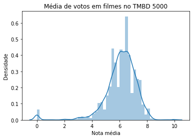

```python
ax = sns.distplot(tmdb.vote_average)
ax.set(xlabel='Nota média', ylabel='Densidade')
ax.set_title('Média de votos em filmes no TMBD 5000')
```

No gráfico acima podemos ver que existem algumas notas zero, mas não sabemos quantas. Podemos ter uma ideia de quantidade se transformarmos o gráfico acima em um gráfico de frequências

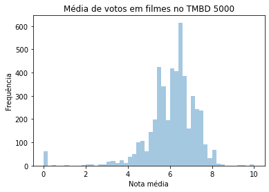

```python
ax = sns.distplot(tmdb.vote_average, norm_hist= False, kde= False)
ax.set(xlabel='Nota média', ylabel='Frequência')
ax.set_title('Média de votos em filmes no TMBD 5000')
```

Vamos ver o boxplot dos dados do dataset. Outra maneira de visualizarmos as informações sobre as notas atribuídas ao filmes. No boxplot abaixo podemos ver a mediana e os quartis do conjunto de notas

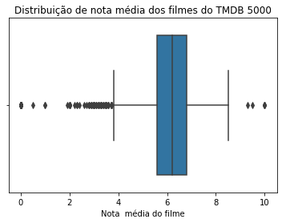

```python
ax = sns.boxplot(tmdb.vote_average)
ax.set(xlabel='Nota  média do filme')
ax.set_title('Distribuição de nota média dos filmes do TMDB 5000')
```

Uma informação importante que podemos extrair dos gráficos acima é que existem uma quantidade razoável de filmes com médias 0 ou 10. Seria incomum isso, pois como o campo é uma média, qualquer nota diferente de 0 ou 10 mudaria essas médias. Isso pode indicar que alguns filmes estão sem notas, ficando com média 0 e também que alguns filmes devem ter tido pouquíssimas notas.

Verificando notas 0

```python
tmdb.query('vote_average == 0 ')[['title','vote_average','vote_count']].head(5)
```

|  | title | vote_average | vote_count |
| --- | --- | --- | --- |
| 1464 | Black Water Transit | 0.0 | 0 |
| 3669 | Should've Been Romeo | 0.0 | 0 |
| 3670 | Running Forever | 0.0 | 0 |
| 3852 | The Secret | 0.0 | 0 |
| 3855 | Time to Choose | 0.0 | 0 |

```python
tmdb.query('vote_average == 0 ').shape
```

```
(63, 20)
```

```python
tmdb.query('vote_average == 0 and vote_count >0 ').shape
```

```
(1, 20)
```

```python
tmdb.query('vote_average == 0 and vote_count >0 ')[['title','vote_average','vote_count']].head(5)
```

|  | title | vote_average | vote_count |
| --- | --- | --- | --- |
| 4400 | Sparkler | 0.0 | 1 |

Com os dados acima, podemos verificar que outras coluna tem a sua importância, a coluna 'vote_count'. A maioria dos filmes com média 0 não possuem votos. Essas notas nos dizem que os filmes seriam ruins, o que não é necessariamente o caso. Vamos remover esses filmes do dataframe. Ainda há o caso de um filme onde recebeu uma única nota 0. Esse filme também será retirado do dataframe por não ser significativo para conclusões estatísticas. Iremos manter no dataframe os registros onde o mínimo de notas seja 20. Em seguida veremos as características do novo conjunto de dados

## Deixando somente os filmes com mais de 20 votos

```python
tmdb_min_20 = tmdb.query('vote_count >= 20')
tmdb_min_20.shape
```

```
(4138, 20)
```

```python
tmdb_min_20.describe()
```

|  | budget | id | popularity | revenue | runtime | vote_average | vote_count |
| --- | --- | --- | --- | --- | --- | --- | --- |
| count | 4.138000e+03 | 4138.000000 | 4138.000000 | 4.138000e+03 | 4138.000000 | 4138.000000 | 4138.000000 |
| mean | 3.333952e+07 | 47549.112615 | 24.745454 | 9.534649e+07 | 109.038183 | 6.264306 | 799.880619 |
| std | 4.224039e+07 | 78793.779006 | 33.138051 | 1.718928e+08 | 20.736348 | 0.862912 | 1297.044864 |
| min | 0.000000e+00 | 5.000000 | 0.011697 | 0.000000e+00 | 0.000000 | 1.900000 | 20.000000 |
| 25% | 4.000000e+06 | 7942.500000 | 7.629479 | 1.013447e+06 | 95.000000 | 5.700000 | 108.000000 |
| 50% | 2.000000e+07 | 12086.500000 | 16.172034 | 3.190530e+07 | 105.000000 | 6.300000 | 325.000000 |
| 75% | 4.500000e+07 | 44935.250000 | 31.791241 | 1.102243e+08 | 119.000000 | 6.900000 | 882.000000 |
| max | 3.800000e+08 | 417859.000000 | 875.581305 | 2.787965e+09 | 338.000000 | 8.500000 | 13752.000000 |

```python
tmdb_min_20.describe().T
```

|  | count | mean | std | min | 25% | 50% | 75% | max |
| --- | --- | --- | --- | --- | --- | --- | --- | --- |
| budget | 4138.0 | 3.333952e+07 | 4.224039e+07 | 0.000000 | 4.000000e+06 | 2.000000e+07 | 4.500000e+07 | 3.800000e+08 |
| id | 4138.0 | 4.754911e+04 | 7.879378e+04 | 5.000000 | 7.942500e+03 | 1.208650e+04 | 4.493525e+04 | 4.178590e+05 |
| popularity | 4138.0 | 2.474545e+01 | 3.313805e+01 | 0.011697 | 7.629479e+00 | 1.617203e+01 | 3.179124e+01 | 8.755813e+02 |
| revenue | 4138.0 | 9.534649e+07 | 1.718928e+08 | 0.000000 | 1.013447e+06 | 3.190530e+07 | 1.102243e+08 | 2.787965e+09 |
| runtime | 4138.0 | 1.090382e+02 | 2.073635e+01 | 0.000000 | 9.500000e+01 | 1.050000e+02 | 1.190000e+02 | 3.380000e+02 |
| vote_average | 4138.0 | 6.264306e+00 | 8.629116e-01 | 1.900000 | 5.700000e+00 | 6.300000e+00 | 6.900000e+00 | 8.500000e+00 |
| vote_count | 4138.0 | 7.998806e+02 | 1.297045e+03 | 20.000000 | 1.080000e+02 | 3.250000e+02 | 8.820000e+02 | 1.375200e+04 |

```python
tmdb_min_20.describe().T.to_csv('../../../dados/tmdb_5000_movies_describe_min_20.csv')
#tmdb.describe().T
```

Agora podemos ver que a nota média minima passou a ser 1.9. Isso significa que todos os filmes tiveram pelo menos uma nota diferente de 0. Perceba que o máximo do campo vote_average também sofreu altereções. Passou a ser 8.5. Isso quer dizer que os filmes no nosso conjunto que apresentavam uma média 10 realmente possuíam pouquissimos votos

Vamos refazer nossos gráficos

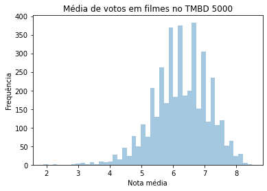

```python
ax = sns.distplot(tmdb_min_20.vote_average, norm_hist= False, kde= False)
ax.set(xlabel='Nota média', ylabel='Frequência')
ax.set_title('Média de votos em filmes no TMBD 5000')
```

O histograma não apresenta mais registros com notas 0 ou 10. Vejamos agora a densidade de notas

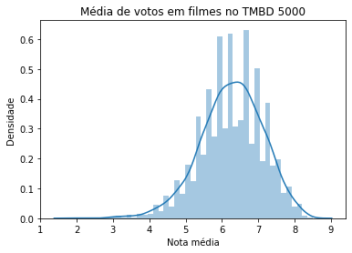

```python
ax = sns.distplot(tmdb_min_20.vote_average)
ax.set(xlabel='Nota média', ylabel='Densidade')
ax.set_title('Média de votos em filmes no TMBD 5000')
```

Temos uma curva semelhante a uma distribuição normal, mas que não é exatamente simétrica, já que possui uma densidade um pouco maior na parte esquerda do gráfico. Veja, também, que analisando essa divisão a partir de uma média visual, existe uma amplitude de valores possíveis maior à esquerda (de 6 até 0) do que na direita (de 6 até 10).

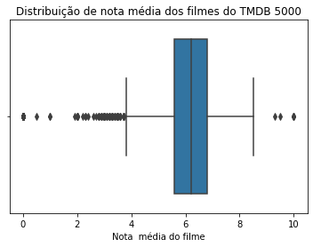

```python
ax = sns.boxplot(tmdb.vote_average)
ax.set(xlabel='Nota  média do filme')
ax.set_title('Distribuição de nota média dos filmes do TMDB 5000')
```

# Resumo dos Dados

## Antes de Limpar os dados

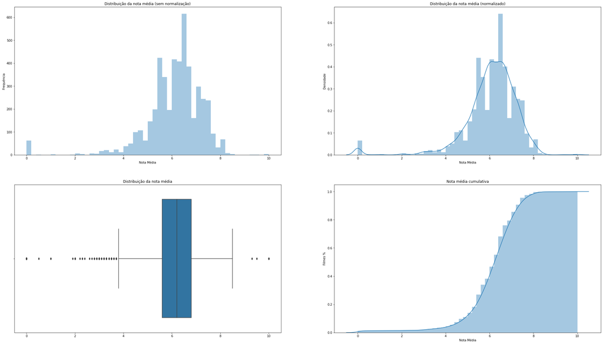

```python
plot_serie(tmdb.vote_average)
```

## Depois de Limpar os dados

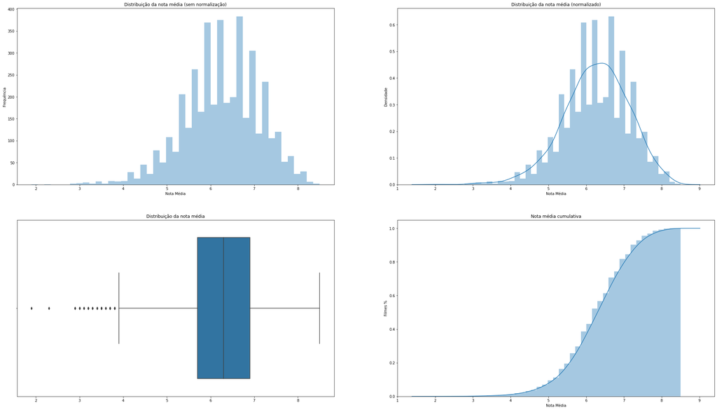

```python
plot_serie(tmdb_min_20.vote_average)
```

# Visualizando e limpando o movielens

Agora, vamos comparar esse conjunto com os dados do MovieLens, procurando saber se esse comportamento se repete. Primeiramente, carregaremos o arquivo ratings.csv e o importaremos, atribuindo essa leitura a uma variável notas. Feito isso, exibiremos os 5 primeiros registros desse dataset:

```python
notas = pd.read_csv("../../../dados/movielens/ml-25m/ratings.csv")
notas.head()
```

|  | userId | movieId | rating | timestamp |
| --- | --- | --- | --- | --- |
| 0 | 1 | 296 | 5.0 | 1147880044 |
| 1 | 1 | 306 | 3.5 | 1147868817 |
| 2 | 1 | 307 | 5.0 | 1147868828 |
| 3 | 1 | 665 | 5.0 | 1147878820 |
| 4 | 1 | 899 | 3.5 | 1147868510 |

### Formato do dataset de notas movieLens

```python
notas.shape
```

```
(25000095, 4)
```

### Tipos de Dados

```python
notas.info()
```

```
<class 'pandas.core.frame.DataFrame'>
RangeIndex: 25000095 entries, 0 to 25000094
Data columns (total 4 columns):
 #   Column     Dtype
---  ------     -----
 0   userId     int64
 1   movieId    int64
 2   rating     float64
 3   timestamp  int64
dtypes: float64(1), int64(3)
memory usage: 762.9 MB
```

### Dados Estatísticos Básicos

```python
notas.describe()
```

|  | userId | movieId | rating | timestamp |
| --- | --- | --- | --- | --- |
| count | 2.500010e+07 | 2.500010e+07 | 2.500010e+07 | 2.500010e+07 |
| mean | 8.118928e+04 | 2.138798e+04 | 3.533854e+00 | 1.215601e+09 |
| std | 4.679172e+04 | 3.919886e+04 | 1.060744e+00 | 2.268758e+08 |
| min | 1.000000e+00 | 1.000000e+00 | 5.000000e-01 | 7.896520e+08 |
| 25% | 4.051000e+04 | 1.196000e+03 | 3.000000e+00 | 1.011747e+09 |
| 50% | 8.091400e+04 | 2.947000e+03 | 3.500000e+00 | 1.198868e+09 |
| 75% | 1.215570e+05 | 8.623000e+03 | 4.000000e+00 | 1.447205e+09 |
| max | 1.625410e+05 | 2.091710e+05 | 5.000000e+00 | 1.574328e+09 |

```python
notas.describe().T
```

|  | count | mean | std | min | 25% | 50% | 75% | max |
| --- | --- | --- | --- | --- | --- | --- | --- | --- |
| userId | 25000095.0 | 8.118928e+04 | 4.679172e+04 | 1.0 | 4.051000e+04 | 8.091400e+04 | 1.215570e+05 | 1.625410e+05 |
| movieId | 25000095.0 | 2.138798e+04 | 3.919886e+04 | 1.0 | 1.196000e+03 | 2.947000e+03 | 8.623000e+03 | 2.091710e+05 |
| rating | 25000095.0 | 3.533854e+00 | 1.060744e+00 | 0.5 | 3.000000e+00 | 3.500000e+00 | 4.000000e+00 | 5.000000e+00 |
| timestamp | 25000095.0 | 1.215601e+09 | 2.268758e+08 | 789652009.0 | 1.011747e+09 | 1.198868e+09 | 1.447205e+09 | 1.574328e+09 |

## Tratamento Inicial do dados

No dataset de notas do movieLens, não exite a nota média para cada filme. Vamos calculá-la

```python
average_vote = notas.groupby("movieId").mean()["rating"]
average_vote.head()
```

```
movieId
1    3.893708
2    3.251527
3    3.142028
4    2.853547
5    3.058434
Name: rating, dtype: float64
```

Em seguida, geraremos a primeira visualização dessas médias. Para isso, repetiremos o processo que fizemos para as médias do TMDB 5000

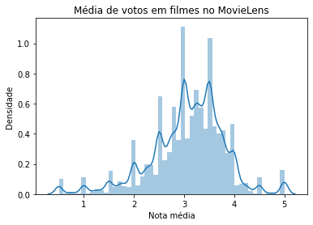

```python
ax = sns.distplot(average_vote.values)
ax.set(xlabel='Nota média', ylabel='Densidade')
ax.set_title('Média de votos em filmes no MovieLens')
```

Dessa vez, temos um gráfico com notas de 0 a 5. Desta vez não temos filmes com média 0, mas temos alguns com média 5. Podemos esperar que devem existir filmes com poucos votos.

```python
qtd_votes_by_movie = notas.groupby("movieId").count()
min_20_votes_movie = qtd_votes_by_movie.query("rating >= 20")
min_20_votes_movie.values
```

```
array([[57309, 57309, 57309],
       [24228, 24228, 24228],
       [11804, 11804, 11804],
       ...,
       [   37,    37,    37],
       [   39,    39,    39],
       [   55,    55,    55]], dtype=int64)
```

### Separando os filmes com pelo menos 20 votos

```python
qtd_votes_by_movie = notas.groupby("movieId").count()
min_20_votes_movie = qtd_votes_by_movie.query("rating >= 20").index
min_20_votes_movie.values
```

```
array([     1,      2,      3, ..., 207309, 207405, 207830], dtype=int64)
```

```python
average_vote_min20 = average_vote.loc[min_20_votes_movie.values]
average_vote_min20.head()
```

```
movieId
1    3.893708
2    3.251527
3    3.142028
4    2.853547
5    3.058434
Name: rating, dtype: float64
```

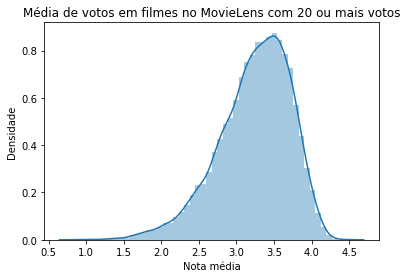

```python
ax = sns.distplot(average_vote_min20)
ax.set(xlabel='Nota média', ylabel='Densidade')
ax.set_title('Média de votos em filmes no MovieLens com 20 ou mais votos')
```

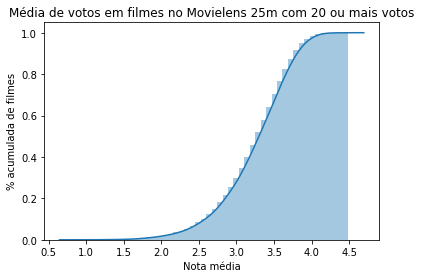

```python
ax = sns.distplot(average_vote_min20.values,
                          hist_kws = {'cumulative':True},
                          kde_kws = {'cumulative':True})
ax.set(xlabel="Nota média", ylabel="% acumulada de filmes")
ax.set_title("Média de votos em filmes no Movielens 25m com 20 ou mais votos")
```

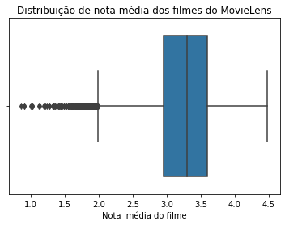

```python
ax = sns.boxplot(x=average_vote_min20.values)
ax.set(xlabel='Nota  média do filme')
ax.set_title('Distribuição de nota média dos filmes do MovieLens')
```

Repare que essa nova visualização também se assemelha àquela do TMDB, com os quartis à esquerda (25% e 50%) mais densos que os da direita.

## Visualizando a CDF

Porém, é difícil afirmarmos algo sobre um filme específico nesse conjunto. Por exemplo, supondo que o filme Toy Story tenha uma nota 3,9... o que isso quer dizer sobre esse filme? É um bom filme? Parece que sim... mas quão bom? E se o determinado filme tiver uma média 3, ele é bom ou ruim? Precisamos entender, agora, como uma nota específica se encaixa dentro dessa distribuição.

Na documentação do distplot() do Seaborn, não existe uma maneira direta de indicarmos essa gradação cumulativa. Porém, o distplot() chama duas funções do matplotlib (hist() e kde()), e pode receber argumentos extras por meio de hist_kws e kde_kws. Dito isso, a função hist() do matploblib tem uma opção cumulative

Portanto, na função displot(), passaremos tanto hist_kws quanto kde_kws recebendo {'cumulative':True}:

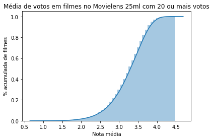

```python
ax = sns.distplot(average_vote_min20.values,
                          hist_kws = {'cumulative':True},
                          kde_kws = {'cumulative':True})
ax.set(xlabel="Nota média", ylabel="% acumulada de filmes")
ax.set_title("Média de votos em filmes no Movielens 25ml com 20 ou mais votos")
```

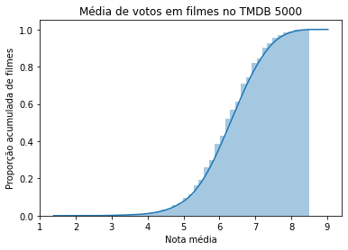

```python
ax = sns.distplot(tmdb_min_20.vote_average,                   hist_kws = {'cumulative':True},                   kde_kws = {'cumulative':True})
ax.set(xlabel='Nota média', ylabel='Proporção acumulada de filmes')
ax.set_title('Média de votos em filmes no TMDB 5000')
```

Visualizando outras informações e quantis quaisquer de forma numérica

## Visualizando outras informações e quantis quaisquer de forma numérica

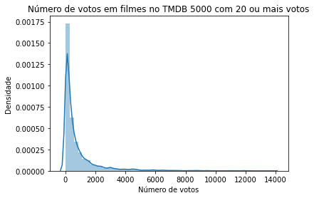

```python
ax = sns.distplot(tmdb_min_20.vote_count)
ax.set(xlabel='Número de votos', ylabel='Densidade')
ax.set_title('Número de votos em filmes no TMDB 5000 com 20 ou mais votos')
```

Como resultado, temos um histograma que, visualmente, lembra uma distribuição com uma queda exponencial - um comportamento bem diferente dos histogramas que geramos anteriormente.

Faz algum sentido, pois quanto mais popular um filme, maior a quantidade de votos que ele terá, e o número de filmes populares certamente é pequeno. No gráfico, isso se traduz no fato de que temos bem mais filmes com menos de 1000 votos do que, por exemplo, filmes com mais de 6000.

Será que podemos repetir esse processo para as outras colunas - por exemplo, o orçamento (budget)? Se exibirmos essa coluna na tela com tmdb.budget, perceberemos que vários registros apresentam o valor 0. Ou seja, provavelmente existem filmes nesse conjunto para os quais essa informação não está disponível, tendo sido preenchidos com esse valor.

No nosso histograma, desejamos manter somente os filmes cujo orçamento seja maior do que 0.

Vejamos o novo gráfico, plotaremos essa distribuição em um histograma

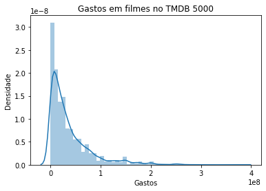

```python
ax = sns.distplot(tmdb.query("budget > 0").budget)
ax.set(xlabel='Gastos', ylabel='Densidade')
ax.set_title('Gastos em filmes no TMDB 5000')
```

Novamente, geramos uma distribuição que cai vertiginosamente. No eixo x, perceba que os valores 1, 2, 3 e 4 são, na verdade, multiplicados por 1e8 - ou seja, por 100000000. Também temos a coluna popularity. Vamos verificar se existem registros com 0 nesse campo:

```python
tmdb.query("popularity == 0").shape
```

```
(1, 20)
```

```python
tmdb.query("popularity == 0")
```

|  | budget | genres | homepage | id | keywords | original_language | original_title | overview | popularity | production_companies | production_countries | release_date | revenue | runtime | spoken_languages | status | tagline | title | vote_average | vote_count |
| --- | --- | --- | --- | --- | --- | --- | --- | --- | --- | --- | --- | --- | --- | --- | --- | --- | --- | --- | --- | --- |
| 4553 | 0 | [] | NaN | 380097 | [] | en | America Is Still the Place | 1971 post civil rights San Francisco seemed li... | 0.0 | [] | [] | NaN | 0 | 0.0 | [] | Released | NaN | America Is Still the Place | 0.0 | 0 |

Vamos assumir, portanto, que esse filme realmente tenha 0 de popularidade. Assim, simplesmente geraremos o histograma dessa coluna:

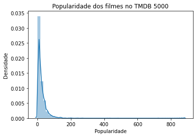

```python
ax = sns.distplot(tmdb.popularity)
ax.set(xlabel='Popularidade', ylabel='Densidade')
ax.set_title('Popularidade dos filmes no TMDB 5000')
```

A queda vertiginosa visualizada nos outros histogramas se repete, demonstrando que pouquíssimos filmes possuem grande popularidade no TMDB. Verificaremos, agora, outro campo presente no nosso conjunto: o tempo de duração dos filmes (runtime).

Entretanto, se tentarmos executar o displot() com tmdb.runtime, retornaremos um ValueError: cannot convert float NaN to integer - ou seja, existem valores que não são números e não podem ser convertidos para integer. Isso pode significar que, no nosso dataset, temos registros com um valor null, que, obviamente, não é um número.

```python
tmdb.runtime.isnull().sum()
```

```
2
```

Na nossa plotagem, então, passaremos tmdb.runtime.dropna(), acrescentando essa função que serve simplesmente para excluir os valores nulos da operação.

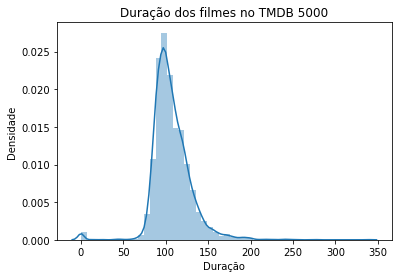

```python
ax = sns.distplot(tmdb.runtime.dropna())
ax.set(xlabel='Duração', ylabel='Densidade')
ax.set_title('Duração dos filmes no TMDB 5000')
```

Perceba que, nessa distribuição, temos um pico de valores 0, o que provavelmente significa que esse campo não foi informado em vários filmes do nosso conjunto. Na nossa nova plotagem, removeremos esses registros com uma query("runtime>0").

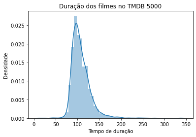

```python
ax = sns.distplot(tmdb.query("runtime>0").runtime.dropna())
ax.set(xlabel='Tempo de duração', ylabel='Densidade')
ax.set_title('Duração dos filmes no TMDB 5000')
```

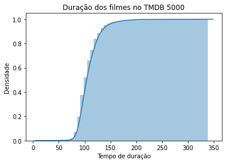

```python
ax = sns.distplot(tmdb.query("runtime>0").runtime.dropna(),
                  hist_kws={'cumulative':True},
                  kde_kws={'cumulative':True})
ax.set(xlabel='Tempo de duração', ylabel='Densidade')
ax.set_title('Duração dos filmes no TMDB 5000')
```

Podemos inferir visualmente, que cerca de 40% dos filmes no conjunto de dados do TMBD têm menos de 100 minutos de duração.

Por meio do Pandas, também existe uma maneira de verificarmos informações como esta de forma numérica. Vamos supor que queremos saber, por exemplo, qual é o valor que separa 80% desse conjunto. Para isso, usaremos a função quantile(), que aceita um parâmetro q com o número decimal referente à porcentagem desejada - nesse caso, 0.8:

```python
tmdb.query("runtime>0").runtime.dropna().quantile(q=0.8)
```

```
121.0
```

Assim, sabemos que 80% dos nossos filmes têm 121 minutos ou menos, e que 20% têm uma duração maior.

```python
tmdb.info()
```

```
<class 'pandas.core.frame.DataFrame'>
RangeIndex: 4803 entries, 0 to 4802
Data columns (total 20 columns):
 #   Column                Non-Null Count  Dtype
---  ------                --------------  -----
 0   budget                4803 non-null   int64
 1   genres                4803 non-null   object
 2   homepage              1712 non-null   object
 3   id                    4803 non-null   int64
 4   keywords              4803 non-null   object
 5   original_language     4803 non-null   object
 6   original_title        4803 non-null   object
 7   overview              4800 non-null   object
 8   popularity            4803 non-null   float64
 9   production_companies  4803 non-null   object
 10  production_countries  4803 non-null   object
 11  release_date          4802 non-null   object
 12  revenue               4803 non-null   int64
 13  runtime               4801 non-null   float64
 14  spoken_languages      4803 non-null   object
 15  status                4803 non-null   object
 16  tagline               3959 non-null   object
 17  title                 4803 non-null   object
 18  vote_average          4803 non-null   float64
 19  vote_count            4803 non-null   int64
dtypes: float64(3), int64(4), object(13)
memory usage: 750.6+ KB
```

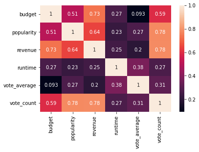

```python
df = pd.DataFrame(tmdb, columns=['budget','popularity',
                                  'revenue','runtime',
                                  'vote_average','vote_count'])
corrMatrix = df.corr()
sns.heatmap(corrMatrix, annot=True)
plt.show()
```

# O efeito do tamanho de uma amostra

Para continuar com nossas análises vamos ver a média das médias dos filmes do movieLens:

```python
average_vote_min20.mean()
```

```
3.237997737700967
```

Sabendo do fato de que a nota mínima no MovieLens é 0,5 e a máxima é 5, poderíamos esperar que a média das médias fosse 2.75. Portanto, em geral, parece que os usuários atribuem notas maiores que 2.75 aos filmes. Será que de repente, se utilizarmos somente 10% da amostra, poderíamos generalizar a média para a amostra inteira?

Vamos começar exibindo a média dos 5 primeiros registros:

```python
average_vote_min20[0:5].mean()
```

```
3.2398489591223765
```

```python
len(average_vote_min20)
```

```
18430
```

```python
medias = list()
for i in range(1, len(average_vote_min20)):
    medias.append(average_vote_min20[0:i].mean())
medias
```

[output not shown]

[output cut: 946 more lines]

[output not shown]

Vamos plotar essas médias em um gráfico para que possamos analisar o seu comportamento. Entaõ começaremos com 1 amostra e vamos acrescentando mais elementos da amostra em nosso conjunto e plotaremos como a média se comporta a medida que o conjunto cresce

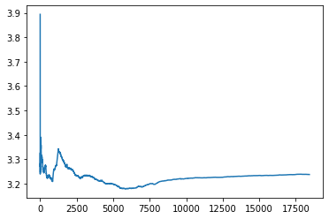

```python
import matplotlib.pyplot as plt
medias = list()
for i in range(1, len(average_vote_min20)):
    medias.append(average_vote_min20[0:i].mean())
plt.plot(medias)
```

Perceba que, no começo, a média tem quedas e elevações abruptas. Porém, em determinado momento do conjunto (por volta dos 10000 registros), a distribuição parece se estabilizar, mantendo-se quase constante. Isso acontece pois, quando temos poucos elementos, cada novo registro no conjunto faz uma diferença bastante significante. Porém, conforme a amostra vai se tornando maior, os novos valores passam a interferir menos no resultado final.

Repare, também, que esses filmes estão em uma ordem específica, fornecida pelo próprio dataset, e não sabemos se essa ordem tem alguma característica oculta que possa estar afetando essa distribuição. Vamos testar isso aleatorizando a ordem do nosso conjunto.

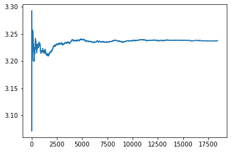

```python
import matplotlib.pyplot as plt
import numpy as np
np.random.seed(75243)
temp = average_vote_min20.sample(frac=1)
medias = list()
for i in range(1, len(temp)):
    medias.append(temp[0:i].mean())
plt.plot(medias)
```

Dessa vez, nosso gráfico começa com valores altos, diminui bastante e então progride de maneira mais estável, tornando-se muito menos sensível à entrada de novas médias.

# Intervalo de confiança da média com t e ztest

Escolhendo os dados de maneira simples, pudemos ver que dependendo do tamanho da amostra e como os dados são escolhidos, essa escolha irá interferir na análise de dados.

O objetivo, então, é utilizarmos o Teste Z para encontrarmos um intervalo de confiança que abrangerá não só os filmes da nossa amostra, mas também aqueles fora dela. Para isso, usaremos a função zconfint() (que se refere ao intervalo de confiança no Teste Z), passando como parâmetro os nossos dados (average_vote_min20). O parâmetro alpha, que é o valor de p, já é previamente configurado como 0.05 (5%).

Para executarmos essa função, teremos que importá-la do módulo statsmodels.stats.weightstats, cuja documentação pode ser encontrada abaixo: Documentação do zfonfint https://www.statsmodels.org/dev/generated/statsmodels.stats.weightstats.zconfint.html

```python
from statsmodels.stats.weightstats import zconfint
#movie lens
zconfint(average_vote_min20)
```

```
(3.2310351155994366, 3.244960359802507)
```

```python
from statsmodels.stats.weightstats import zconfint
#tmdb
zconfint(tmdb_min_20.vote_average          )
```

```
(6.238014699215095, 6.290598157237297)
```

Nos cursos de estatística, aprendemos que existem outros tipos de testes, como o Teste t, e existem diferenças primordiais entre eles. Ambos exigem algumas características na nossa distribuição ou nos nossos dados, mas, em linhas gerais, utilizamos o Teste Z quando temos um conjunto maior, e o Teste T quando esse conjunto é menor. Como nossa amostra pode ser considerada grande, executaremos o Teste T apenas para verificarmos o resultado.

Nesse caso, o processo é um pouquinho mais trabalhoso, pois teremos que descrever os nossos dados de forma estatística com o DescrStatsW. https://www.statsmodels.org/dev/generated/statsmodels.stats.weightstats.DescrStatsW.html#statsmodels.stats.weightstats.DescrStatsW

```python
from statsmodels.stats.weightstats import DescrStatsW
descr_todos_com_10_votos = DescrStatsW(average_vote_min20)
descr_todos_com_10_votos
```

```
<statsmodels.stats.weightstats.DescrStatsW at 0x1ff0ca19070>
```

```python
descr_todos_com_10_votos.tconfint_mean()
```

```
(3.2310346582845444, 3.2449608171173994)
```

O intervalo de confiança utilizando o teste T é muito parecido com aquele que encontramos com o Teste Z. Claro, cada teste é utilizado em situações distintas, de acordo com a necessidade.

# ZTest para uma amostra

```python
filmes = pd.read_csv("../../../dados/movielens/ml-25m/movies.csv")
filmes.query("movieId==1")
```

|  | movieId | title | genres |
| --- | --- | --- | --- |
| 0 | 1 | Toy Story (1995) | Adventure\|Animation\|Children\|Comedy\|Fantasy |

```python
notas1 = notas.query("movieId ==1")
notas1.head()
```

|  | userId | movieId | rating | timestamp |
| --- | --- | --- | --- | --- |
| 70 | 2 | 1 | 3.5 | 1141415820 |
| 254 | 3 | 1 | 4.0 | 1439472215 |
| 910 | 4 | 1 | 3.0 | 1573944252 |
| 1152 | 5 | 1 | 4.0 | 858625949 |
| 1304 | 8 | 1 | 4.0 | 890492517 |

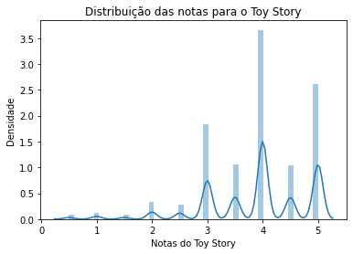

```python
ax = sns.distplot(notas1.rating)
ax.set(xlabel='Notas do Toy Story', ylabel='Densidade')
ax.set_title('Distribuição das notas para o Toy Story')
```

No MovieLens, as notas são dadas em gradações de 0.5 (0,5, 1, 1.5 e assim por diante). Como esses valores não estão distribuídos de forma contínua, plotaremos também o boxplot do conjunto:

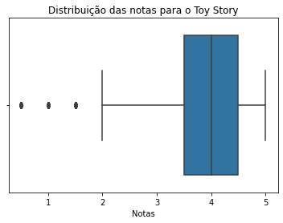

```python
ax = sns.boxplot(notas1.rating)
ax.set(xlabel='Notas')
ax.set_title('Distribuição das notas para o Toy Story')
```

```python
average_vote_min20.median()
```

```
3.299241335708949
```

```python
average_vote_min20.mean()
```

```
3.237997737700967
```

Essa visualização nos permite interpretar melhor a distribuição dos nossos dados. Por exemplo, a mediana está posicionada na nota 4 e parece existir uma densidade semelhante nos dois quartis imediatamente adjacentes. Como 5 é a nota máxima, as notas não se distribuem muito para a direita, ao contrário do que acontece para a esquerda.

Visualmente, a mediana 4 do Toy Story já é bastante superior à mediana 3,2992 que tínhamos na distribuição das notas médias dos filmes do movieLens com 20 ou mais votos. Porém, será que essa percepção se sustenta na realidade? Afinal, pode ser que os nossos dados estejam enviesados.

Mesmo que fossem três pessoas completamente aleatórias, ainda existiria uma chance de que todas elas dessem a mesma nota, e as nossas informações seriam, então, fruto do acaso.

Vamos calcular a média de notas do Toy Story:

```python
notas1.rating.mean()
```

```
3.893707794587238
```

Realmente, a média dos dados que coletamos é maior do que a média dos filmes com pelo menos 20 votos, que era 3.2379. Mas será que essa diferença é real? Ou ela é fruto do acaso? Para termos uma análise mais objetiva dessa média, já que temos mais de 30 registros no nosso conjunto, podemos aplicar o Teste Z:

```python
zconfint(notas1.rating)
```

```
(3.886162842774441, 3.9012527464000346)
```

Também podemos realizar outro teste com as nossas médias, tentando afirmar que a nota média do Toy Story na verdade é a nota média que encontramos para os filmes com pelo menos vinte votos. Vamos fazer um novo teste Z que nos retorna um pvalue confirmando se, no mundo real, a média desse filme seria ou não igual a 3.237997737700967 (a nota média do movieLens).

```python
from statsmodels.stats.weightstats import ztest
ztest(notas1.rating, value = 3.237997737700967)
```

```
(170.33483151185402, 0.0)
```

O ztest() nos devolve duas variáveis: o valor estatístico e o pvalue. Repare que este último é 0, e menor que o nosso 0.05 (o alpha). Portanto, podemos descartar a hipótese de que, no mundo real, a média do Toy Story é igual a 3. 237997737700967 (também chamada de hipótese nula).

Quando trabalhamos com bigdata, acabamos caindo nesse tipo de problema, e torna-se mais interessante analisarmos não só a possibilidade dessa igualdade, como também o intervalo de confiança e as visualizações gráficas das nossas distribuições.

Nesse momento, nossa conclusão é que o filme Toy Story realmente tem uma média diferente da média de todos os filmes.